# Single Linkage Hierarchical Clustering

# Introduction

Single linkage clustering merges the two clusters whose **minimum pairwise distance** is the smallest among all pairs. When clusters have multiple members, the distance between them is defined as the **minimum distance between any pair of points** across clusters.

# 1. Setting up the data

We start with a simple dataset of 8 individuals with weight (kg) and height (cm).

```r
weight.kg <- c(15, 49, 13, 45, 85, 66, 12, 10)
height.cm <- c(95, 156, 95, 160, 178, 176, 90, 78)

data <- matrix(cbind(weight.kg, height.cm), nrow = 8)
dimnames(data)[[2]] <- c("weight.kg", "height.cm")
data
```

```
##      weight.kg height.cm
## [1,]        15        95
## [2,]        49       156
## [3,]        13        95
## [4,]        45       160
## [5,]        85       178
## [6,]        66       176
## [7,]        12        90
## [8,]        10        78
```

# 2. Visualizing the data

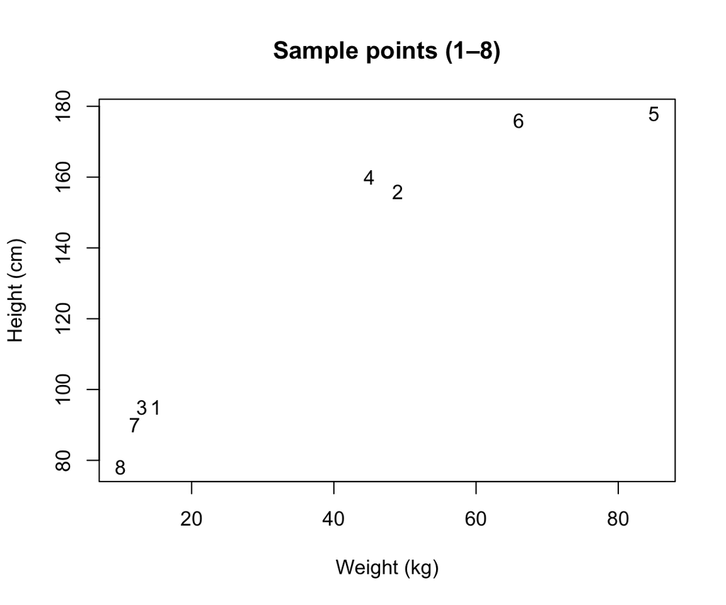

```r
plot(data[,1], data[,2], type = "n",
     xlab = "Weight (kg)", ylab = "Height (cm)",
     main = "Sample points (1–8)")
text(data[,1], data[,2], labels = 1:8)
```

This scatter plot helps visualize the relative proximity of the data points.

# 3. Pairwise distances

We compute the Euclidean distances between all pairs of observations.

```r
# Pairwise distances
dist_matrix <- dist(data, diag = TRUE, upper = TRUE)
round(dist_matrix, 2)
```

```
##        1      2      3      4      5      6      7      8
## 1   0.00  69.84   2.00  71.59 108.58  95.72   5.83  17.72
## 2  69.84   0.00  70.83   5.66  42.19  26.25  75.66  87.21
## 3   2.00  70.83   0.00  72.45 109.88  96.80   5.10  17.26
## 4  71.59   5.66  72.45   0.00  43.86  26.40  77.39  89.16
## 5 108.58  42.19 109.88  43.86   0.00  19.10 114.34 125.00
## 6  95.72  26.25  96.80  26.40  19.10   0.00 101.55 112.87
## 7   5.83  75.66   5.10  77.39 114.34 101.55   0.00  12.17
## 8  17.72  87.21  17.26  89.16 125.00 112.87  12.17   0.00
```

`dist()` calculates the Euclidean distance by default. You can verify distances manually:

```r
sqrt((49 - 45)^2 + (156 - 160)^2)
```

```
## [1] 5.656854
```

# 4. Hierarchical clustering (Single linkage)

The `hclust()` function performs hierarchical clustering. We specify `method = "single"` to use **minimum inter-cluster distance**.

```r
hclust.single <- hclust(dist(data), method = "single")

# Structure of result
names(hclust.single)
```

```
## [1] "merge"       "height"      "order"       "labels"      "method"
## [6] "call"        "dist.method"
```

```r
hclust.single$height
```

```
## [1]  2.000000  5.099020  5.656854 12.165525 19.104973 26.248809 69.835521
```

`$height` gives the distances (linkage heights) at which clusters merge.

# 5. Dendrogram

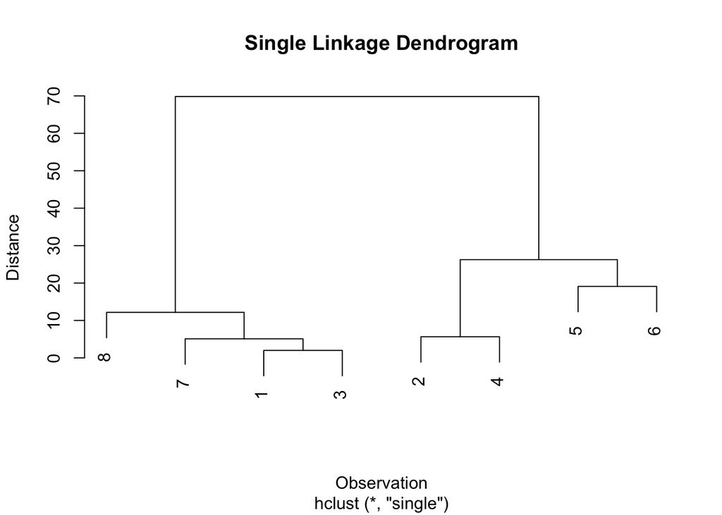

```r
plot(hclust.single, main = "Single Linkage Dendrogram",
     xlab = "Observation", ylab = "Distance")
```

This plot shows how clusters are formed iteratively based on minimum distance.

# 6. Manual first iteration

We can manually verify the algorithm. First, compute all pairwise distances and find the minimum.

```r
dist <- dist(data, diag = TRUE)
round(dist, 2)
```

```
##        1      2      3      4      5      6      7      8
## 1   0.00
## 2  69.84   0.00
## 3   2.00  70.83   0.00
## 4  71.59   5.66  72.45   0.00
## 5 108.58  42.19 109.88  43.86   0.00
## 6  95.72  26.25  96.80  26.40  19.10   0.00
## 7   5.83  75.66   5.10  77.39 114.34 101.55   0.00
## 8  17.72  87.21  17.26  89.16 125.00 112.87  12.17   0.00
```

```r
min(as.dist(dist)[as.dist(dist) != 0])  # smallest nonzero distance
```

```
## [1] 2
```

The smallest distance corresponds to the pair (1,3). These two points will be merged first.

# 7. Updating distances after merging (Clusters 1 & 3)

We manually update the distance matrix using the **single linkage rule** — distance between clusters = *minimum* pairwise distance.

```r
old.dist <- as.matrix(dist)
new.dist <- old.dist

# Set intra-cluster distance to 0 for merged points
new.dist[1,3] <- new.dist[3,1] <- 0

# Update distances for cluster (1,3)
for (i in 1:8) {
  new.dist[1,i] <- new.dist[i,1] <- min(old.dist[1,i], old.dist[3,i])
  new.dist[3,i] <- new.dist[i,3] <- min(old.dist[1,i], old.dist[3,i])
}

# Verify matrix symmetry
all.equal(new.dist, t(new.dist))
```

```
## [1] TRUE
```

```r
round(as.dist(new.dist), 2)
```

```
##        1      2      3      4      5      6      7
## 2  69.84
## 3   0.00  69.84
## 4  71.59   5.66  71.59
## 5 108.58  42.19 108.58  43.86
## 6  95.72  26.25  95.72  26.40  19.10
## 7   5.10  75.66   5.10  77.39 114.34 101.55
## 8  17.26  87.21  17.26  89.16 125.00 112.87  12.17
```

# 8. Next iteration (Merging 7 with cluster 1–3)

We continue by finding the next smallest distance and merging.

```r
min(as.dist(new.dist)[as.dist(new.dist) != 0])  # 5.099
```

```
## [1] 5.09902
```

```r
# Merge cluster (1,3) with point 7
new.dist2 <- new.dist
for (i in 1:8) {
  new.dist2[1,i] <- new.dist2[i,1] <-
    min(old.dist[1,i], old.dist[3,i], old.dist[7,i])
}
all.equal(new.dist2, t(new.dist2))
```

```
## [1] TRUE
```

```r
round(as.dist(new.dist2), 3)
```

```
##         1       2       3       4       5       6       7
## 2  69.836
## 3   0.000  69.836
## 4  71.589   5.657  71.589
## 5 108.577  42.190 108.577  43.863
## 6  95.718  26.249  95.718  26.401  19.105
## 7   0.000  75.664   5.099  77.389 114.337 101.548
## 8  12.166  87.207  17.263  89.157 125.000 112.872  12.166
```

# 9. Merge (2,4) cluster

Similarly, we merge points (2,4) and update distances.

```r
min(as.dist(new.dist2)[as.dist(new.dist2) != 0])  # 5.657
```

```
## [1] 5.09902
```

```r
new.dist3 <- new.dist2
for (i in 1:8) {
  new.dist3[2,i] <- new.dist3[i,2] <-
    min(old.dist[2,i], old.dist[4,i])
}
round(as.dist(new.dist3), 3)
```

```
##         1       2       3       4       5       6       7
## 2  69.836
## 3   0.000  70.831
## 4  71.589   0.000  71.589
## 5 108.577  42.190 108.577  43.863
## 6  95.718  26.249  95.718  26.401  19.105
## 7   0.000  75.664   5.099  77.389 114.337 101.548
## 8  12.166  87.207  17.263  89.157 125.000 112.872  12.166
```

The smallest distance after this step corresponds to the next merge (8 with cluster 1,3,7).

# 10. Compare manual and automated results

```r
hclust.single$height
```

```
## [1]  2.000000  5.099020  5.656854 12.165525 19.104973 26.248809 69.835521
```

The merge heights from `hclust()` match our manual computation: `2.00, 5.10, 5.66, 12.17, ...`

# 11. Define clusters

We can “cut” the dendrogram at a specific number of clusters (`k`) or a given height (`h`).

```r
# Cut into 2 clusters
cut.single <- cutree(hclust.single, k = 2)
cut.single
```

```
## [1] 1 2 1 2 2 2 1 1
```

```r
# Alternatively, cut at height threshold
cut.single <- cutree(hclust.single, h = 20)
cut.single
```

```
## [1] 1 2 1 2 3 3 1 1
```

These assignments group samples based on single linkage distance.

# Summary

- **Single linkage** = merge by *minimum* pairwise distance.
- Sensitive to **chaining** (long elongated clusters).
- `hclust()` reproduces manual results efficiently.
- Can visualize structure via **dendrogram** or **cluster assignments**.